```python
from IPython.display import HTML
HTML('''<style>html, body{overflow-y: visible !important} .CodeMirror{min-width:105% !important;} .rise-enabled .CodeMirror, .rise-enabled .output_subarea{font-size:140%; line-height:1.2; overflow: visible;} .output_subarea pre{width:110%}</style>''') # For slides
```

# Foundations of Data Mining: Assignment 1

Please complete all assignments in this notebook. You should submit this notebook, as well as a PDF version (See File > Download as).

```python
# Please fill in your names here
NAME_STUDENT_1 = "Robin Esposito"
NAME_STUDENT_2 = "Matej Grobelnik"
```

```python
%matplotlib inline
from preamble import *
plt.rcParams['savefig.dpi'] = 100 # This controls the size of your figures
# Comment out and restart notebook if you only want the last output of each cell.
#InteractiveShell.ast_node_interactivity = "all"
```

## MoneyBall (5 points, 1+2+1+1)

In the early 2000s, 2 baseball scouts completely changed the game of baseball by analysing the available data about baseball players and hiring the best ones. The [MoneyBall dataset](https://www.openml.org/d/41021) contains this data (click the link for more details). The goal is to accurately predict the number of 'runs' each player can score.

```python
moneyball = oml.datasets.get_dataset(41021) # Download MoneyBall data
# Get the predictors X and the target y
X, y, attribute_names = moneyball.get_data(target=moneyball.default_target_attribute, return_attribute_names=True)
# Describe the data with pandas, just to get an overview
ballframe = pd.DataFrame(X, columns=attribute_names)
ballframe.describe()
```

|  | Team | League | Year | RA | ... | RankPlayoffs | G | OOBP | OSLG |
| --- | --- | --- | --- | --- | --- | --- | --- | --- | --- |
| count | 1232.00 | 1232.0 | 1232.00 | 1232.00 | ... | 244.00 | 1232.00 | 420.00 | 420.00 |
| mean | 15.67 | 0.5 | 1988.96 | 715.08 | ... | 1.72 | 3.92 | 0.33 | 0.42 |
| std | 9.72 | 0.5 | 14.82 | 93.08 | ... | 1.10 | 0.62 | 0.02 | 0.03 |
| min | 0.00 | 0.0 | 1962.00 | 472.00 | ... | 0.00 | 0.00 | 0.29 | 0.35 |
| 25% | 7.00 | 0.0 | 1976.75 | 649.75 | ... | 1.00 | 4.00 | 0.32 | 0.40 |
| 50% | 16.00 | 0.5 | 1989.00 | 709.00 | ... | 2.00 | 4.00 | 0.33 | 0.42 |
| 75% | 23.00 | 1.0 | 2002.00 | 774.25 | ... | 3.00 | 4.00 | 0.34 | 0.44 |
| max | 38.00 | 1.0 | 2012.00 | 1103.00 | ... | 4.00 | 7.00 | 0.38 | 0.50 |

8 rows × 14 columns

1 . Visually explore the data. Plot the distribution of each feature (e.g. histograms), as well as the target. Visualize the dependency of the target on each feature (use a 2d scatter plot). Is there anything that stands out? Is there something that you think might require special treatment?

- Feel free to create additional plots that help you understand the data
- Only visualize the data, you don't need to change it (yet)

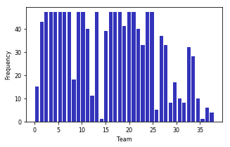

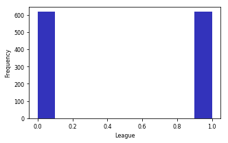

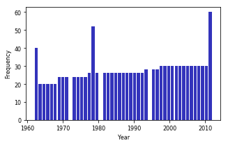

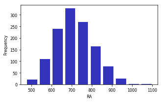

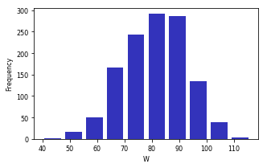

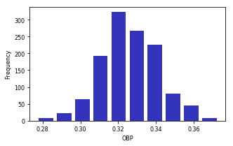

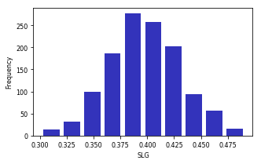

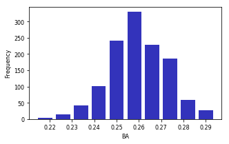

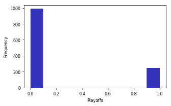

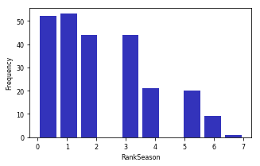

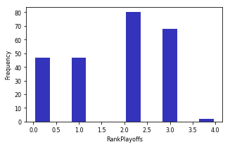

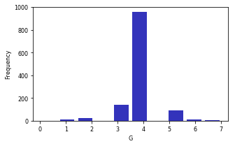

[2 more figures not shown]

```python
#Histograms
ax = ballframe['Team'].plot.hist(alpha=0.8, bins=ballframe['Team'].nunique(), rwidth=0.8)
ax.set_xlabel('Team')
plt.show()

ax = ballframe['League'].plot.hist(alpha=0.8)
ax.set_xlabel('League')
plt.show()

ax = ballframe['Year'].plot.hist(alpha=0.8, bins=ballframe['Year'].nunique(), rwidth=0.8)
ax.set_xlabel('Year')
plt.show()

ax = ballframe['RA'].plot.hist(alpha=0.8, rwidth=0.8)
ax.set_xlabel('RA')
plt.show()

ax = ballframe['W'].plot.hist(alpha=0.8, rwidth=0.8)
ax.set_xlabel('W')
plt.show()

ax = ballframe['OBP'].plot.hist(alpha=0.8, rwidth=0.8)
ax.set_xlabel('OBP')
plt.show()

ax = ballframe['SLG'].plot.hist(alpha=0.8, rwidth=0.8)
ax.set_xlabel('SLG')
plt.show()

ax = ballframe['BA'].plot.hist(alpha=0.8, rwidth=0.8)
ax.set_xlabel('BA')
plt.show()

ax = ballframe['Playoffs'].plot.hist(alpha=0.8)
ax.set_xlabel('Playoffs')
plt.show()

ax = ballframe['RankSeason'].plot.hist(alpha=0.8, rwidth=0.8)
ax.set_xlabel('RankSeason')
plt.show()

ax = ballframe['RankPlayoffs'].plot.hist(alpha=0.8, rwidth=0.8)
ax.set_xlabel('RankPlayoffs')
plt.show()

ax = ballframe['G'].plot.hist(alpha=0.8, rwidth=0.8)
ax.set_xlabel('G')
plt.show()

ax = ballframe['OOBP'].plot.hist(alpha=0.8, rwidth=0.8)
ax.set_xlabel('OOBP')
plt.show()

ax = ballframe['OSLG'].plot.hist(alpha=0.8, rwidth=0.8)
ax.set_xlabel('OSLG')
plt.show()
```

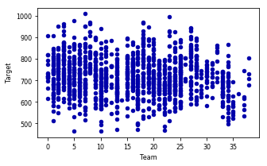

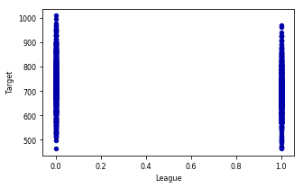

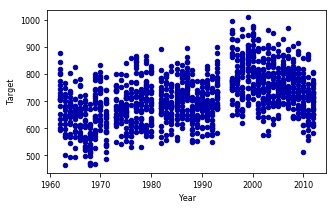

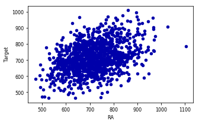

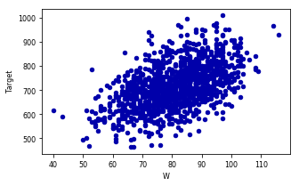

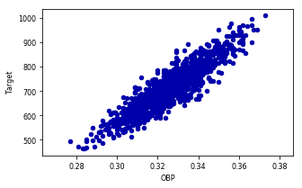

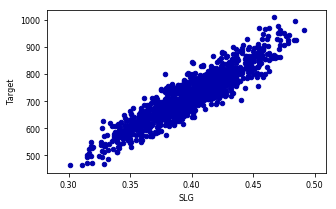

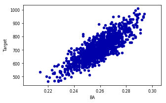

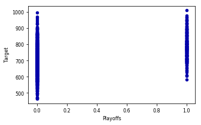

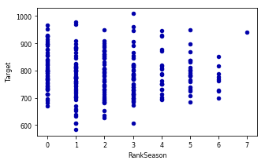

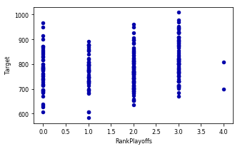

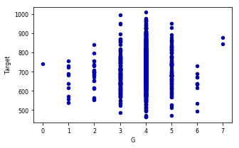

[2 more figures not shown]

```python
#2d scatter plots
ballframe_with_target = ballframe.join(pd.DataFrame({'Target':y}))

ballframe_with_target.plot(kind='scatter', x='Team', y='Target')

ballframe_with_target.plot(kind='scatter', x='League', y='Target')

ballframe_with_target.plot(kind='scatter', x='Year', y='Target')

ballframe_with_target.plot(kind='scatter', x='RA', y='Target')

ballframe_with_target.plot(kind='scatter', x='W', y='Target')

ballframe_with_target.plot(kind='scatter', x='OBP', y='Target')

ballframe_with_target.plot(kind='scatter', x='SLG', y='Target')

ballframe_with_target.plot(kind='scatter', x='BA', y='Target')

ballframe_with_target.plot(kind='scatter', x='Playoffs', y='Target')

ballframe_with_target.plot(kind='scatter', x='RankSeason', y='Target')

ballframe_with_target.plot(kind='scatter', x='RankPlayoffs', y='Target')

ballframe_with_target.plot(kind='scatter', x='G', y='Target')

ballframe_with_target.plot(kind='scatter', x='OOBP', y='Target')

ballframe_with_target.plot(kind='scatter', x='OSLG', y='Target');
```

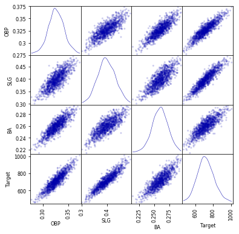

```python
# Further data exploration
from pandas.tools.plotting import scatter_matrix
scatter_matrix(ballframe_with_target[["OBP", "SLG", "BA", "Target"]], alpha=0.2, figsize=(6, 6), diagonal='kde');
```

Many of the features in the dataset have discrete values, but all of them are already encoded as numeric values. Two of the features ("League" and "Playoffs") are binary and can only assume value 0 or 1. Among the features with continuous values, "OBP", "SLG" and "BA" seem to have a linear correlation to the target, as we can see from the scatter plots. We also plotted a separate scatter matrix, to emphasize the strict correlation between these three features and the target values.

In other features, such as "RA" and "W", the plot is a bit more sparse but it is still possible to visually identify some correlation. "OOBP" and "OSLG", on the other hand, have a very low correlation to the target, and therefore these two features will not be particularly useful in the prediction of target values. The visualized plots do not show many outliers in the dataset.

Four of the features have missing values: "RankSeason", "RankPlayoffs", "OOBP", "OSLG". We will drop these features in order to work on the dataset.

2 . Compare all linear regression algorithms that we covered in class (Linear Regression, Ridge, Lasso and ElasticNet), as well as kNN. Evaluate using cross-validation and the $R^2$ score, with the default parameters. Does scaling the data with StandardScaler help? Provide a concise but meaningful interpretation of the results.

- Preprocess the data as needed (e.g. are there nominal features that are not ordinal?). If you don't know how to proceed, remove the feature and continue.

```python
# Preprocessing
from sklearn.preprocessing import StandardScaler
from sklearn.pipeline import Pipeline

filtered_df = ballframe_with_target.dropna(axis="columns")
X = filtered_df.iloc[:,0:10].values
y = filtered_df.iloc[:,10].values
```

```python
# Linear Regression
from sklearn.model_selection import train_test_split
from sklearn.linear_model import LinearRegression
from sklearn.model_selection import cross_val_score
from sklearn.datasets import load_iris

lr = LinearRegression()
scores = cross_val_score(lr, X, y)
print("Cross-validation scores: {}".format(scores))
print("Average cross-validation score: {:.2f}".format(scores.mean()))

#with scaling
pipe = Pipeline([("scaler", StandardScaler()), ("lr", LinearRegression())])
scores_scaled = cross_val_score(pipe, X, y)
print("\nCross-validation scores (scaled): {}".format(scores_scaled))
print("Average cross-validation score (scaled): {:.2f}".format(scores_scaled.mean()))
```

```
Cross-validation scores: [ 0.92   0.928  0.934]
Average cross-validation score: 0.93

Cross-validation scores (scaled): [ 0.92   0.928  0.934]
Average cross-validation score (scaled): 0.93
```

```python
# Ridge regression
from sklearn.linear_model import Ridge

ridge = Ridge()
scores = cross_val_score(ridge, X, y)
print("Cross-validation scores: {}".format(scores))
print("Average cross-validation score: {:.2f}".format(scores.mean()))

#with scaling
pipe = Pipeline([("scaler", StandardScaler()), ("ridge", Ridge())])
scores_scaled = cross_val_score(pipe, X, y)
print("\nCross-validation scores (scaled): {}".format(scores_scaled))
print("Average cross-validation score (scaled): {:.2f}".format(scores_scaled.mean()))
```

```
Cross-validation scores: [ 0.833  0.877  0.857]
Average cross-validation score: 0.86

Cross-validation scores (scaled): [ 0.92   0.928  0.934]
Average cross-validation score (scaled): 0.93
```

```python
# Lasso
from sklearn.linear_model import Lasso

lasso = Lasso()
scores = cross_val_score(lasso, X, y)
print("Cross-validation scores: {}".format(scores))
print("Average cross-validation score: {:.2f}".format(scores.mean()))

#with scaling
pipe = Pipeline([("scaler", StandardScaler()), ("lasso", Lasso())])
scores_scaled = cross_val_score(pipe, X, y)
print("\nCross-validation scores (scaled): {}".format(scores_scaled))
print("Average cross-validation score (scaled): {:.2f}".format(scores_scaled.mean()))
```

```
Cross-validation scores: [ 0.804  0.848  0.828]
Average cross-validation score: 0.83

Cross-validation scores (scaled): [ 0.917  0.925  0.939]
Average cross-validation score (scaled): 0.93
```

```python
# ElasticNet
from sklearn.linear_model import ElasticNet

en = ElasticNet()
scores = cross_val_score(en, X, y)
print("Cross-validation scores: {}".format(scores))
print("Average cross-validation score: {:.2f}".format(scores.mean()))

#with scaling
pipe = Pipeline([("scaler", StandardScaler()), ("en", ElasticNet())])
scores_scaled = cross_val_score(pipe, X, y)
print("\nCross-validation scores (scaled): {}".format(scores_scaled))
print("Average cross-validation score (scaled): {:.2f}".format(scores_scaled.mean()))
```

```
Cross-validation scores: [ 0.803  0.849  0.828]
Average cross-validation score: 0.83

Cross-validation scores (scaled): [ 0.879  0.885  0.894]
Average cross-validation score (scaled): 0.89
```

```python
# kNN
from sklearn.neighbors import KNeighborsRegressor

neigh = KNeighborsRegressor()
scores = cross_val_score(neigh, X, y)
print("Cross-validation scores: {}".format(scores))
print("Average cross-validation score: {:.2f}".format(scores.mean()))

#with scaling
pipe = Pipeline([("scaler", StandardScaler()), ("neigh", KNeighborsRegressor())])
scores_scaled = cross_val_score(pipe, X, y)
print("\nCross-validation scores (scaled): {}".format(scores_scaled))
print("Average cross-validation score (scaled): {:.2f}".format(scores_scaled.mean()))
```

```
Cross-validation scores: [ 0.468  0.665  0.46 ]
Average cross-validation score: 0.53

Cross-validation scores (scaled): [ 0.842  0.867  0.757]
Average cross-validation score (scaled): 0.82
```

From the obtained cross-validation scores, we can observe that the Linear Regression model has the same result with and without scaling, while all the other models benefit significatively from scaling. The reason for this is that scaling is effective for all the models in which some kind of regularization is applied, while in the linear model it can be useful for interpreting the data, but it does not affect the actual regression model. In all regularized models scaling brings a significative improvement, but the model in which scaling has the strongest effect is the K-Neighbors Regressor: it changes the avarage R^2 score from 0.53 to 0.82.

3 . Do a default, shuffled train-test split and optimize the linear models for the degree of regularization ($alpha$) and choice of penalty (L1/L2). For Ridge and Lasso, plot a curve showing the effect of the training and test set performance ($R^2$) while increasing the degree of regularization for different penalties. For ElasticNet, plot a heatmap $alpha \times l1\_ratio \rightarrow R^2$ using test set performance. Report the optimal performance. Again, provide a concise but meaningful interpretation. What does the regularization do? Can you get better results?

- Think about how you get the L1/L2 loss. This is not a hyperparameter in regression.
- We've seen how to generate such heatmaps in Lecture 3.

```python
# Default shuffled split and scaling
X_train, X_test, y_train, y_test = train_test_split(X, y, shuffle=True, random_state=0)
print("Size of training set: {}\nSize of test set: {}\n".format(X_train.shape[0], X_test.shape[0]))

scaler = StandardScaler()
X_train_scaled = scaler.fit_transform(X_train)
X_test_scaled = scaler.transform(X_test)

# range [0..1] for parameters tuning
range_01 = [0, 0.001, 0.01, 0.1, 0.5, 0.9, 0.99, 0.999, 1]
```

```
Size of training set: 924
Size of test set: 308
```

Since the Linear Regression model does not allow for L1/L2 regularization, we tried to optimize it by adding polyomial features, to introduce non-linearity in the model. We tried several polynomial degrees and we found the optimal one to be 2.

```python
# Linear regression with polynomial features
from sklearn.preprocessing import PolynomialFeatures
best_score = 0
lr_scores = []

for degree in [2,3,5,7]:
    poly = PolynomialFeatures(degree=degree, include_bias=False).fit(X_train_scaled)
    X_train_poly = poly.transform(X_train_scaled)
    X_test_poly = poly.transform(X_test_scaled)

    reg = LinearRegression().fit(X_train_poly, y_train)
    score = reg.score(X_test_poly, y_test)
    lr_scores.append(score)
    if score > best_score:
        best_score = score
        best_parameters = {'degree': degree}

print("Best score: {:.6f}".format(best_score))
print("Best parameters: {}".format(best_parameters))
```

```
Best score: 0.948745
Best parameters: {'degree': 2}
```

```
Best score: 0.950848
Best parameters: {'alpha': 1}
```

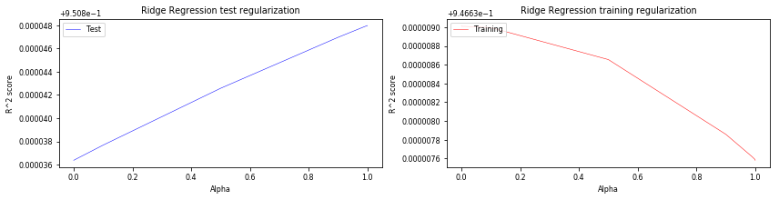

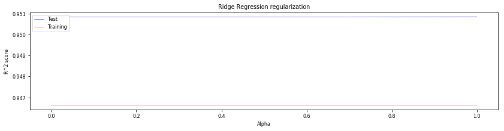

```python
# Ridge Regression (L2)
best_score = 0
ridge_train_scores = []
ridge_test_scores = []

for alpha in range_01:
    ridge = Ridge(alpha=alpha).fit(X_train_scaled, y_train)
    score = ridge.score(X_test_scaled, y_test)
    ridge_test_scores.append(score)
    ridge_train_scores.append(ridge.score(X_train_scaled, y_train))
    if score > best_score:
        best_score = score
        best_parameters = {'alpha': alpha}

fig1=plt.figure(figsize=(14,3))
fig1.show()
ax1=fig1.add_subplot(121)
ax1.plot(range_01,ridge_test_scores,c='b',ls='-',label='Test')
plt.legend(loc=2)
plt.title("Ridge Regression test regularization")
plt.xlabel("Alpha")
plt.ylabel("R^2 score")
ax2=fig1.add_subplot(122)
ax2.plot(range_01,ridge_train_scores,c='r',ls='-',label='Training')
plt.legend(loc=2)
plt.title("Ridge Regression training regularization")
plt.xlabel("Alpha")
plt.ylabel("R^2 score")
plt.draw()

fig2=plt.figure(figsize=(14,3))
fig2.show()
ax=fig2.add_subplot(111)
ax.plot(range_01,ridge_test_scores,c='b',ls='-',label='Test')
ax.plot(range_01,ridge_train_scores,c='r',ls='-',label='Training')
plt.legend(loc=2)
plt.title("Ridge Regression regularization")
plt.xlabel("Alpha")
plt.ylabel("R^2 score")
plt.draw()

print("Best score: {:.6f}".format(best_score))
print("Best parameters: {}".format(best_parameters))
```

```
Best score: 0.950886
Best parameters: {'alpha': 0.1}
```

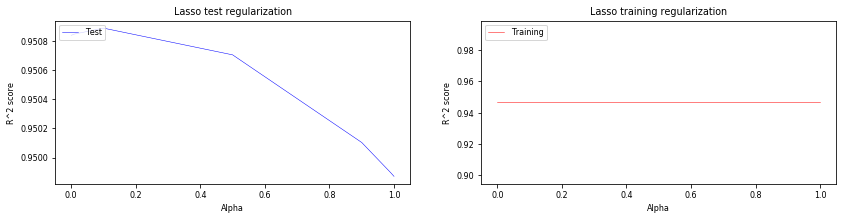

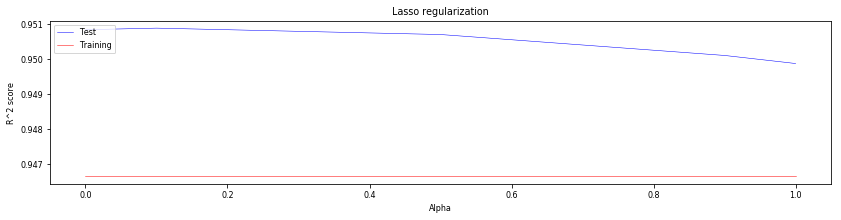

```python
# Lasso (L1)
best_score = 0
lasso_train_scores = []
lasso_test_scores = []

for alpha in range_01:
    lasso = Lasso(alpha=alpha).fit(X_train_scaled, y_train)
    score = lasso.score(X_test_scaled, y_test)
    lasso_test_scores.append(score)
    lasso_train_scores.append(ridge.score(X_train_scaled, y_train))
    if score > best_score:
        best_score = score
        best_parameters = {'alpha': alpha}


fig1=plt.figure(figsize=(14,3))
fig1.show()
ax1=fig1.add_subplot(121)
ax1.plot(range_01,lasso_test_scores,c='b',ls='-',label='Test')
plt.legend(loc=2)
plt.title("Lasso test regularization")
plt.xlabel("Alpha")
plt.ylabel("R^2 score")
ax2=fig1.add_subplot(122)
ax2.plot(range_01,lasso_train_scores,c='r',ls='-',label='Training')
plt.legend(loc=2)
plt.title("Lasso training regularization")
plt.xlabel("Alpha")
plt.ylabel("R^2 score")
plt.draw()

fig2=plt.figure(figsize=(14,3))
fig2.show()
ax=fig2.add_subplot(111)
ax.plot(range_01,lasso_test_scores,c='b',ls='-',label='Test')
ax.plot(range_01,lasso_train_scores,c='r',ls='-',label='Training')
plt.legend(loc=2)
plt.title("Lasso regularization")
plt.xlabel("Alpha")
plt.ylabel("R^2 score")
plt.draw()


print("Best score: {:.6f}".format(best_score))
print("Best parameters: {}".format(best_parameters))
```

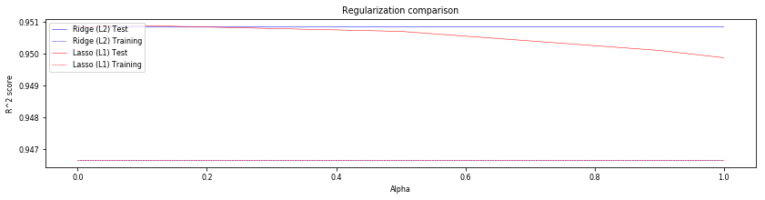

```python
# Ridge Regression vs Lasso comparison

fig=plt.figure(figsize=(14,3))
fig.show()
ax=fig.add_subplot(111)
ax.plot(range_01,ridge_test_scores,c='b',ls='-',label='Ridge (L2) Test')
ax.plot(range_01,ridge_train_scores,c='b',ls='--',label='Ridge (L2) Training')
ax.plot(range_01,lasso_test_scores,c='r',ls='-',label='Lasso (L1) Test')
ax.plot(range_01,lasso_train_scores,c='r',ls='--',label='Lasso (L1) Training')
plt.legend(loc=2)
plt.title("Regularization comparison")
plt.xlabel("Alpha")
plt.ylabel("R^2 score")
plt.draw()
```

```
Best score: 0.950886
Best parameters: {'alpha': 0.1, 'l1_ratio': 1}
```

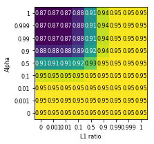

```python
# Elastic Net (L1/L2 tradeoff)
best_score = 0
en_scores = pd.DataFrame(columns=range_01)

for alpha in range_01:
    row = []
    for l1_ratio in range_01:
        en = ElasticNet(alpha=alpha, l1_ratio=l1_ratio).fit(X_train_scaled, y_train)
        score = en.score(X_test_scaled, y_test)
        row.append(score)
        if score > best_score:
            best_score = score
            best_parameters = {'alpha': alpha, 'l1_ratio': l1_ratio}
    en_scores.loc[alpha] = row

# plot the mean cross-validation scores
scores = en_scores.values
mglearn.tools.heatmap(scores, xlabel='L1 ratio', xticklabels=range_01,
ylabel='Alpha', yticklabels=range_01, cmap="viridis");

print("Best score: {:.6f}".format(best_score))
print("Best parameters: {}".format(best_parameters))
```

**Overview of the optimized performances:**

When using Ridge Regression, which adopts L2 regularization, the best R^2 score is obtained for the maximal value of alpha (1), meaning that the model benefits from a very strong regularization to reduce the variance of estimates. Contrarily, in the Lasso model (based on L1 regulatization) the optimal value is found for a very low but not minimale value of alpha (0.1), implying that a stronger regularization is counterproductive.

In the Elastic Net model, the optimal value corresponds to a L1 ratio of 1 (full L1 penalty) and an alpha value of 0.1, which brings us back to the same properties and same R^2 score of the Lasso model. As visible from the heatmap, the worst performances are located in the top-left corner, which represents L2 regularization for a high alpha parameter, while all other corners of the map show fairly high R^2 values.

L2 prefers to have many small values, while L1 gives a better performance for many values close to 0 and some very large values, making it robust to ouliers. Interpreting our results, which finds in L1 regularization the best option for our model, we could probably achieve an even better result with a more detailed preprocessing of the data, focused on outliers removal.

4 . Visualize the coefficients of the optimized models. Do they agree on which features are important? Compare the results with the feature importances returned by a RandomForest. Does it agree with the linear models? What would look for when scouting for a baseball player?

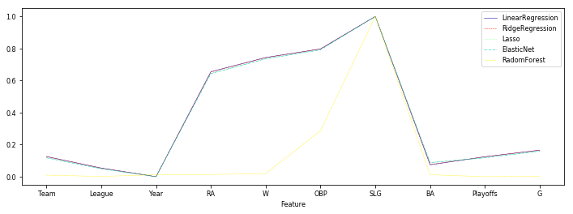

```python
from sklearn import preprocessing
df = pd.DataFrame(columns=ballframe.dropna(axis="columns").columns)

# scale data (fitting on the whole dataset)
scaler = StandardScaler()
X_scaled = scaler.fit_transform(X)

# Linear Regression
lr = LinearRegression().fit(X_scaled, y)
coef = lr.coef_
df.loc['LinearRegression'] = coef

# Ridge Regression
ridge = Ridge(alpha=1).fit(X_scaled, y)
coef = ridge.coef_
df.loc['RidgeRegression'] = coef

# Lasso
lasso = Lasso(alpha=0.1).fit(X_scaled, y)
coef = lasso.coef_
df.loc['Lasso'] = coef

#Elastic Net
en = ElasticNet(alpha=0.1, l1_ratio=1).fit(X_scaled, y)
coef = en.coef_
df.loc['ElasticNet'] = coef

# Random Forest
from sklearn.ensemble import RandomForestRegressor
rf = RandomForestRegressor(n_estimators=100, random_state=42)
rf.fit(X_scaled, y)
importances = rf.feature_importances_
df.loc['RadomForest'] = importances



# use features as index for better visualization
df = df.T
df = df.reindex(df.index.rename('Feature'))

# scale values for visual comparison
min_max_scaler = preprocessing.MinMaxScaler()
values_scaled = min_max_scaler.fit_transform(df.values)
df = pd.DataFrame(values_scaled, index=df.index, columns=df.columns)

ax = df.plot(figsize=(12,4))
ax.set_xticks(range(0, 10))
ax.set_xticklabels(df.index)
plt.legend(loc='best');
```

The scores were normalized in order to easily indentify the most imporant features in each model. The optimized linear models have very similiar coefficients, as visible from the graph above, while the RandomForest has some similarities but also some notable differences. In both cases "Team", "League", "Year", "BA", "Playoffs" and "G", have relatively small importance, while "SLG" has maximal importance. But while in Random Forest "RA" and "W" have very low importance (and "OBP" relatively low), in the linear models their scores are significatively high.

Ultimately, the most important feature to consider when scouting for a baseball player are (in order): "SLG", "OBP", "W" and "RA", which is quite coherent to what we supposed in the data exploration section, but with some unexpected changes.